# Código_Compra_Cartera

```python
# En primer lugar se cargan las librerías necesarias para el desarrollo del problema
import numpy as np
import pandas as pd
import matplotlib.pyplot as plp
```

```python
#Se procede a la lectura de los datos, la información será almacenada de la siguiente manera:
# Datos Davivienda -> Información de los datos de entradas (mayoría de variables) y variable de salida
#Dartos mensuales: Datos de los datos que presentan lag por mes
Datos_Davivienda=pd.read_csv('dav_data.csv', header=0)
Datos_Mensuales=pd.read_csv('datos_mesuales.csv', header=0)
```

```python
#Se visualiza la información para notar que fue cargada correctamente
Datos_Davivienda.head()
Datos_Mensuales.head()
```

|  | CONSECUTIVO | mes_lag | MORA_DAV | MORA_SF | NUM_CONS |
| --- | --- | --- | --- | --- | --- |
| 0 | 1 | 0 | 0.0 | 0.0 | 2.0 |
| 1 | 1 | 1 | 0.0 | 0.0 | 2.0 |
| 2 | 1 | 2 | 0.0 | 0.0 | 3.0 |
| 3 | 1 | 3 | 0.0 | 0.0 | 3.0 |
| 4 | 2 | 0 | 0.0 | 0.0 | 2.0 |

```python
#Se comprueba si la matriz cargada contiene datos vacíos o no numéricos
#El resultado es que si
Datos_Davivienda.isnull().any().any()
```

```
True
```

```python
#Se convierte a columna cada una de las lags de las variables de Datos_mensuales, de tal manera que se aumente el número de columnas de acuerdo  la
#lag respectiva, de esta manera la nueva matriz Datos_arreglados tendrá 13 columnas, la incical CONSECUTIVO, y las variables
#MORA_DAV|zero,MORA_DAV|one,MORA_DAV|two,MORA_DAV|three, MORA_SF|zero,MORA_SF|one,MORA_SF|two,MORA_SF|three,NUM_CONS|zero,NUM_CONS|one,NUM_CONS|two,NUM_CONS|three
#Esto reduce el número de filas y aumenta el de columnas.
Datos_arreglados= Datos_Mensuales.pivot(index='CONSECUTIVO',columns='mes_lag', values=['MORA_DAV','MORA_SF','NUM_CONS'])
Datos_arreglados.columns.set_levels(['zero','one','two','three'],level=1,inplace=True)
Datos_arreglados.columns = Datos_arreglados.columns.map('|'.join).str.strip('|')
#Datos_arreglados.loc[:,'MORA_DAV|zero':'MORA_SF|three'] = Datos_arreglados.loc[:,'MORA_DAV|zero':'MORA_SF|three'].astype('bool')
Datos_arreglados.reset_index(level=['CONSECUTIVO'], inplace=True)

#Se procede a visualizar los datos para notar que quedaron arreglados correctamente
Datos_arreglados.head()
```

|  | CONSECUTIVO | MORA_DAV\|zero | MORA_DAV\|one | MORA_DAV\|two | MORA_DAV\|three | MORA_SF\|zero | MORA_SF\|one | MORA_SF\|two | MORA_SF\|three | NUM_CONS\|zero | NUM_CONS\|one | NUM_CONS\|two | NUM_CONS\|three |
| --- | --- | --- | --- | --- | --- | --- | --- | --- | --- | --- | --- | --- | --- |
| 0 | 1 | 0.0 | 0.0 | 0.0 | 0.0 | 0.0 | 0.0 | 0.0 | 0.0 | 2.0 | 2.0 | 3.0 | 3.0 |
| 1 | 2 | 0.0 | 0.0 | 0.0 | 0.0 | 0.0 | 0.0 | 0.0 | 0.0 | 2.0 | 0.0 | 0.0 | 0.0 |
| 2 | 3 | 0.0 | 0.0 | 0.0 | 0.0 | 0.0 | 0.0 | 0.0 | 0.0 | 1.0 | 4.0 | 4.0 | 3.0 |
| 3 | 4 | 0.0 | 0.0 | 0.0 | 0.0 | 0.0 | 0.0 | 0.0 | 0.0 | 1.0 | 1.0 | 1.0 | 0.0 |
| 4 | 5 | 0.0 | 0.0 | 0.0 | 0.0 | 0.0 | 0.0 | 0.0 | 0.0 | 1.0 | 1.0 | 1.0 | 0.0 |

```python
#Se imprimen los nombres de las columnas de la nueva matriz
print(Datos_arreglados.columns)
```

```
Index(['CONSECUTIVO', 'MORA_DAV|zero', 'MORA_DAV|one', 'MORA_DAV|two',
       'MORA_DAV|three', 'MORA_SF|zero', 'MORA_SF|one', 'MORA_SF|two',
       'MORA_SF|three', 'NUM_CONS|zero', 'NUM_CONS|one', 'NUM_CONS|two',
       'NUM_CONS|three'],
      dtype='object')
```

```python
#Se unen las dos matrices de datos en una sola datos, de tal manera que se compacte la información
datos=pd.merge(Datos_Davivienda,Datos_arreglados)
datos.head()
```

|  | CONSECUTIVO | COMPRA_CARTERA | EDAD | ACIERTA | QUANTO | ACT_LAB | ANT_DAV | SALDO_DAV_ANT | SALDO_DAV_ACT | CUPO_DAV | ... | MORA_DAV\|two | MORA_DAV\|three | MORA_SF\|zero | MORA_SF\|one | MORA_SF\|two | MORA_SF\|three | NUM_CONS\|zero | NUM_CONS\|one | NUM_CONS\|two | NUM_CONS\|three |
| --- | --- | --- | --- | --- | --- | --- | --- | --- | --- | --- | --- | --- | --- | --- | --- | --- | --- | --- | --- | --- | --- |
| 0 | 1 | 1 | 50.0 | 894.0 | 14227.0 | I | 3.08 | 6884.26 | 3092.32 | 68900.0 | ... | 0.0 | 0.0 | 0.0 | 0.0 | 0.0 | 0.0 | 2.0 | 2.0 | 3.0 | 3.0 |
| 1 | 2 | 1 | 60.0 | 654.0 | 8322.0 | E | 14.08 | 3504.91 | 1534.87 | 5599.0 | ... | 0.0 | 0.0 | 0.0 | 0.0 | 0.0 | 0.0 | 2.0 | 0.0 | 0.0 | 0.0 |
| 2 | 3 | 0 | 40.0 | 806.0 | 1681.0 | E | 4.50 | 1231.00 | 1637.00 | 0.0 | ... | 0.0 | 0.0 | 0.0 | 0.0 | 0.0 | 0.0 | 1.0 | 4.0 | 4.0 | 3.0 |
| 3 | 4 | 1 | 40.0 | 807.0 | 12661.0 | E | 1.50 | 13282.84 | 1360.74 | 11999.0 | ... | 0.0 | 0.0 | 0.0 | 0.0 | 0.0 | 0.0 | 1.0 | 1.0 | 1.0 | 0.0 |
| 4 | 5 | 0 | 50.0 | 823.0 | 1697.0 | NaN | 0.92 | 1019.00 | 1019.00 | 1999.0 | ... | 0.0 | 0.0 | 0.0 | 0.0 | 0.0 | 0.0 | 1.0 | 1.0 | 1.0 | 0.0 |

5 rows × 31 columns

```python
#Se agrupan las variables por tipo
tipos_Datos = datos.columns.to_series().groupby(datos.dtypes).groups
# se guardan en la lista categoricas las variables que no sean numéricas
categoricas = tipos_Datos[np.dtype('object')]
columnastotales = datos.columns
categoricas=list(set(categoricas))
# Se aumenta la lista de categoricas adicionando las variables que a pesar de ser numéricas son discretas
categoricas.extend(['EDAD','MORA_DAV|zero', 'MORA_DAV|one', 'MORA_DAV|two','MORA_DAV|three', 'MORA_SF|zero', 'MORA_SF|one', 'MORA_SF|two',
       'MORA_SF|three', 'NUM_CONS|zero', 'NUM_CONS|one', 'NUM_CONS|two',
       'NUM_CONS|three','NUM_PROD_P1','NUM_PROD_P2','NUM_PROD_P3','NUM_PROD_P4'])
#Se guarda en variable numericas todas aquellas que no sean categoricas
numericas = [e for e in list(set(columnastotales)) if e not in categoricas]
numericas = [e for e in numericas if e not in ['CONSECUTIVO','COMPRA_CARTERA']]
#Se elimina la variable ENTIDAD_COMPRA de las variables categoricas, ya que es normal que esta variable no presente información
categoricas = [e for e in categoricas if e not in ['ENTIDAD_COMPRA']]
```

```python
#Se llenan todos los datos vacios de las variables numéricas continuas con la mediana de los datos
for c in numericas:
    mediana = datos[c].median()
    datos[c] = datos[c].fillna(mediana)
```

```python
#Se llenan todos los datos faltantes de las variables categoricas o discretas con la moda
for c in categoricas:
    moda = datos[c].mode()[0]
    datos[c] = datos[c].fillna(moda)
```

```python
#Se crea una categoría para los datos faltantes de la variable ENTIDAD_COMPRA
datos['ENTIDAD_COMPRA']=datos['ENTIDAD_COMPRA'].fillna("Ninguna")
```

```python
#Se agreg esta variable al listado de categóricas
categoricas.extend(['ENTIDAD_COMPRA'])
```

```python
#Se calcula el porcentaje e lo registros que poseen compra de cartera, dado a que se obtiene como resultado 43% se puede concluir
#que los datos pueden usarse tranquilamente para el entrenamiento, pues no hay un desbalance entre las etiquetas de la salida
porcentaje_compra=datos[datos.COMPRA_CARTERA==1]['COMPRA_CARTERA'].count()/datos['COMPRA_CARTERA'].count()
print(porcentaje_compra*100)
```

```
43.738894603946505
```

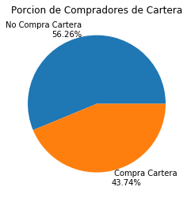

```python
# se crea el Grafico de totas del porcentaje de compra de cartera para una mejor visualización
# Agrupando por COMPRA_CARTERA
compradores = datos.groupby('COMPRA_CARTERA').CONSECUTIVO.count()
# Creando las leyendas del grafico.
labels = [ ' Compra Cartera\n' + str(round(x * 1.0 / compradores.sum() * 100.0, 2)) + '%'  for x in compradores ]
labels[0] = 'No' + labels[0]

plp.pie(compradores, labels=labels)
plp.title('Porcion de Compradores de Cartera')
plp.show()
#Se genera el gráfico
```

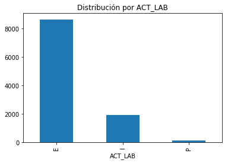

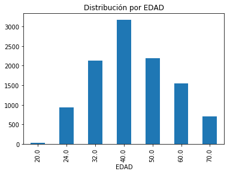

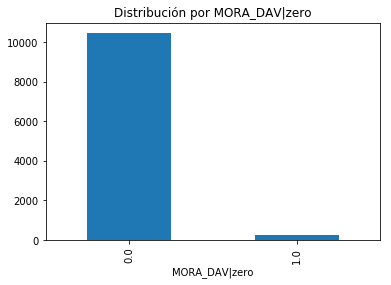

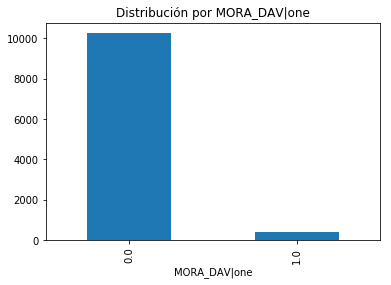

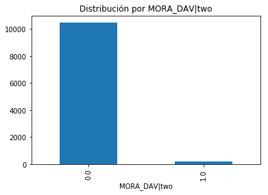

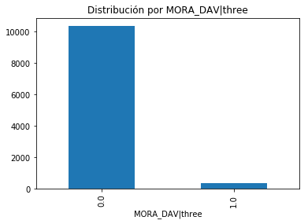

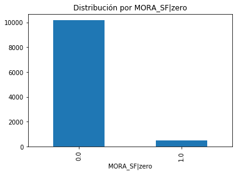

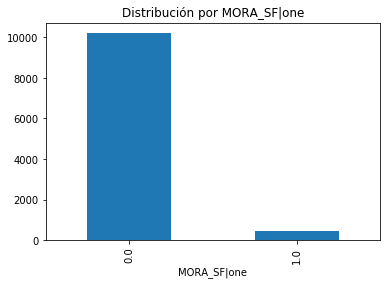

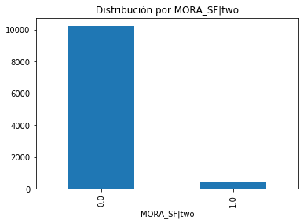

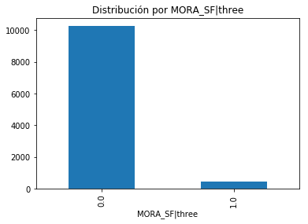

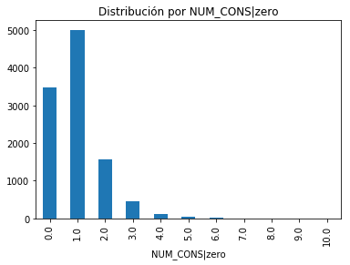

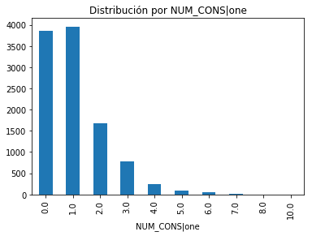

[8 more figures not shown]

```python
#Para todas las variables categóricas se crea un gráfico que permita observar el histograma de las variables.
for c in categoricas:
    datos.groupby(c).size().plot(kind='bar')
    plp.title('Distribución por '+ c)
    plp.show()

datos.groupby('ENTIDAD_COMPRA').size().plot(kind='bar')
plp.title('Distribución por ENTIDAD_COMPRA')
plp.show()
```

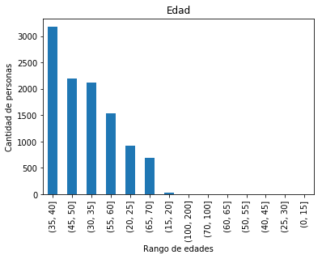

```python
# Se analiza y grafica la variable edad, partiendo las edades por rangos
imp_segm = pd.cut(datos['EDAD'],
                  [0, 15, 20, 25, 30, 35, 40, 45, 50, 55, 60, 65, 70, 100, 200])
# Creando el grafico de barras desde pandas
plot = pd.value_counts(imp_segm).plot(kind='bar',
                                      title='Edad')
plot.set_ylabel('Cantidad de personas')
plot.set_xlabel('Rango de edades')
plp.show()
```

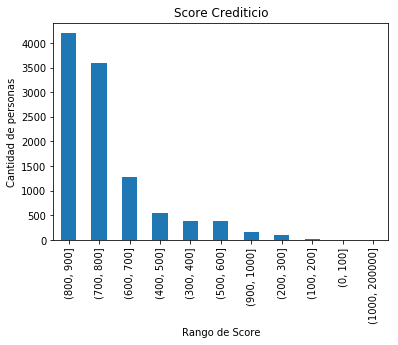

```python
# Se analiza y grafica la variable score crediticio, partiendo las scores crediticios por rangos
imp_segm = pd.cut(datos['ACIERTA'], [0, 100,200,300,400, 500,600,700,800,900,1000,200000])
# Creando el grafico de barras desde pandas
plot = pd.value_counts(imp_segm).plot(kind='bar',
                                      title='Score Crediticio')
plot.set_ylabel('Cantidad de personas')
plot.set_xlabel('Rango de Score')
plp.show()
```

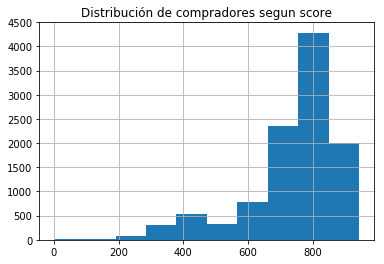

```python
#Se crea un histograma para la variable SCORE, para observar su distribución
datos['ACIERTA'].hist().set_title('Distribución de compradores segun score')
plp.show()
```

```python
#Se hallan las estadísticas descriptivas de las variables a ser procesadas
print(datos.describe())
datos3=pd.merge(Datos_Davivienda,Datos_arreglados)
print(datos3.describe().QUANTO)
```

```
        CONSECUTIVO  COMPRA_CARTERA          EDAD       ACIERTA        QUANTO  \
count  10693.000000    10693.000000  10693.000000  10693.000000  10693.000000
mean    5347.000000        0.437389     43.856729    737.566819   6665.307023
std     3086.947548        0.496088     12.562885    143.263697   5951.736716
min        1.000000        0.000000     20.000000      3.000000      0.000000
25%     2674.000000        0.000000     32.000000    697.000000   2707.000000
50%     5347.000000        0.000000     40.000000    779.000000   4496.000000
75%     8020.000000        1.000000     50.000000    835.000000   8645.000000
max    10693.000000        1.000000     70.000000    942.000000  71143.000000

            ANT_DAV  SALDO_DAV_ANT  SALDO_DAV_ACT       CUPO_DAV  \
count  10693.000000   10693.000000   10693.000000   10693.000000
mean       5.926432   12583.977357    9110.981690   15929.730945
std        7.804880   20854.242585   18813.487169   26181.007214
min        0.000000       0.000000       0.000000       0.000000
25%        1.170000    2137.670000     717.000000    1299.000000
50%        2.750000    5107.000000    2301.000000    6599.000000
75%        7.580000   13542.320000    9027.000000   19400.000000
max       55.250000  360538.000000  360044.000000  545000.000000

             ANT_SF  ...  MORA_DAV|two  MORA_DAV|three  MORA_SF|zero  \
count  10693.000000  ...  10693.000000    10693.000000  10693.000000
mean       6.518806  ...      0.020200        0.030581      0.047040
std        6.242564  ...      0.140691        0.172187      0.211735
min        0.000000  ...      0.000000        0.000000      0.000000
25%        1.830000  ...      0.000000        0.000000      0.000000
50%        5.080000  ...      0.000000        0.000000      0.000000
75%        9.830000  ...      0.000000        0.000000      0.000000
max       49.170000  ...      1.000000        1.000000      1.000000

        MORA_SF|one   MORA_SF|two  MORA_SF|three  NUM_CONS|zero  NUM_CONS|one  \
count  10693.000000  10693.000000   10693.000000   10693.000000  10693.000000
mean       0.043860      0.042925       0.040026       0.967081      1.085757
std        0.204794      0.202698       0.196030       0.941936      1.168644
min        0.000000      0.000000       0.000000       0.000000      0.000000
25%        0.000000      0.000000       0.000000       0.000000      0.000000
50%        0.000000      0.000000       0.000000       1.000000      1.000000
75%        0.000000      0.000000       0.000000       1.000000      2.000000
max        1.000000      1.000000       1.000000      10.000000     10.000000

       NUM_CONS|two  NUM_CONS|three
count  10693.000000    10693.000000
mean       1.127092        0.625269
std        1.220318        0.981852
min        0.000000        0.000000
25%        0.000000        0.000000
50%        1.000000        0.000000
75%        2.000000        1.000000
max       10.000000        8.000000

[8 rows x 29 columns]
count    10689.000000
mean      6666.118814
std       5952.702349
min          0.000000
25%       2707.000000
50%       4496.000000
75%       8645.000000
max      71143.000000
Name: QUANTO, dtype: float64
```

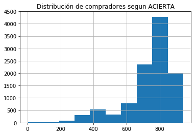

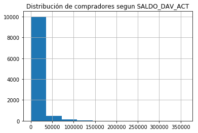

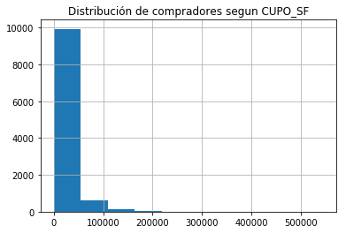

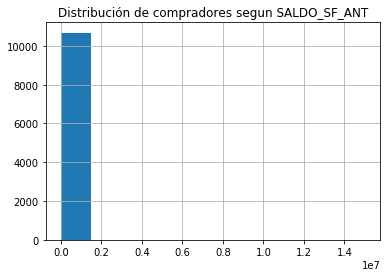

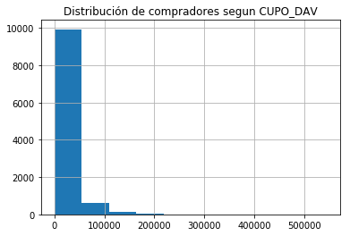

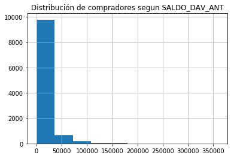

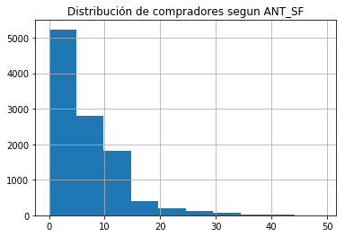

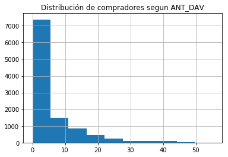

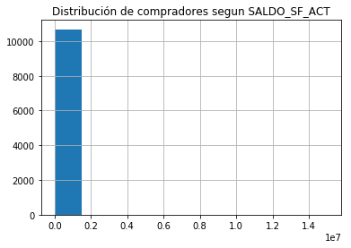

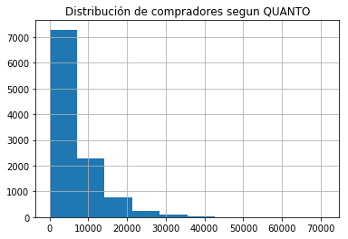

```python
#Se realiza el histograma de todas las variables numéricas continuas
for c in numericas:
    datos[c].hist().set_title('Distribución de compradores segun '+ c)
    plp.show()
#Se observa que existen múltiples variables que son outliers
```

```python
#Se realiza el reemplazo de los outliers en las variables continuas por la mediana de la variable, para esto se usa el algoritmo iqr
#En donde se consideran outlieers los datos inferiores al percentil25-1.5*(percentil 75- percentil 25) y superiores al
#percentil75+1.5*(percentil 75- percentil 25)
for c in numericas:
    ordenado=sorted(datos[c])
    outliers=[]
    q1, q3= np.percentile(ordenado,[25,75])
    iqr = q3 - q1
    lower_bound = max(0,q1 -(1.5 * iqr))
    upper_bound = q3 +(1.5 * iqr)
    datosup = datos.loc[datos[c]<upper_bound, c]
    median = datosup.loc[datosup> lower_bound].median()
    datos.loc[datos[c]>=upper_bound, c] = np.nan
    datos.loc[datos[c]<=lower_bound, c] = np.nan
    datos.fillna(median,inplace=True)
```

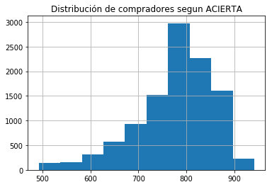

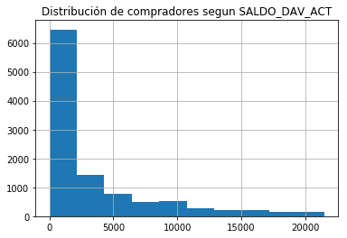

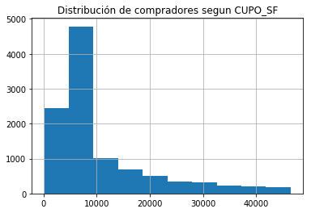

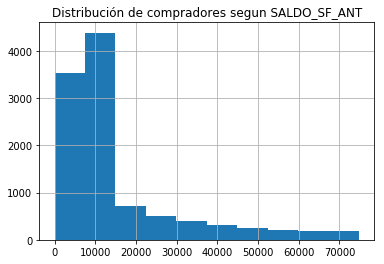

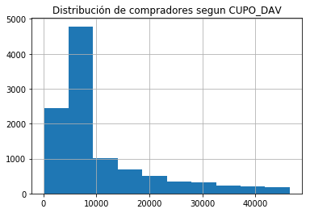

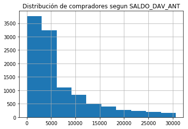

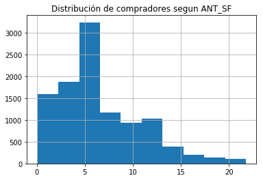

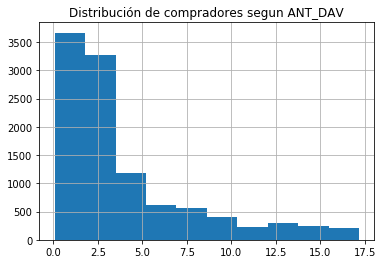

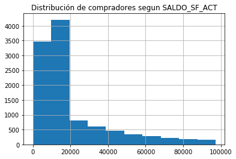

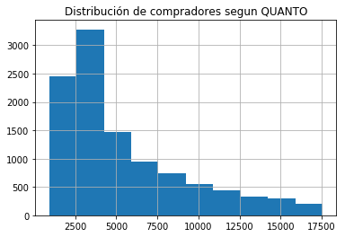

```python
#Se vuelve a graficar el histograma de las variables para observar la remoción de outliers
for c in numericas:
    datos[c].hist().set_title('Distribución de compradores segun '+ c)
    plp.show()
```

```python
#Se hallan nuevamente las estadísticas descriptivas de los datos para notar que se han eliminado los otliers
print(datos.describe())
print(datos.describe().SALDO_SF_ACT)
```

```
        CONSECUTIVO  COMPRA_CARTERA          EDAD       ACIERTA        QUANTO  \
count  10693.000000    10693.000000  10693.000000  10693.000000  10693.000000
mean    5347.000000        0.437389     43.856729    777.162349   5491.828112
std     3086.947548        0.496088     12.562885     80.365548   3807.056613
min        1.000000        0.000000     20.000000    492.000000    919.000000
25%     2674.000000        0.000000     32.000000    735.000000   2707.000000
50%     5347.000000        0.000000     40.000000    790.000000   4181.000000
75%     8020.000000        1.000000     50.000000    835.000000   7328.000000
max    10693.000000        1.000000     70.000000    942.000000  17547.000000

            ANT_DAV  SALDO_DAV_ANT  SALDO_DAV_ACT      CUPO_DAV        ANT_SF  \
count  10693.000000   10693.000000   10693.000000  10693.000000  10693.000000
mean       3.899936    6667.244099    3700.272322  11065.948658      6.566048
std        3.904093    6578.653305    4588.417648   9522.669711      4.275538
min        0.080000       1.000000       0.010000     99.000000      0.080000
25%        1.250000    2152.620000     840.840000   5100.000000      3.420000
50%        2.500000    4243.000000    1832.280000   8399.000000      5.750000
75%        5.000000    8917.300000    4571.200000  12599.000000      9.000000
max       17.170000   30638.000000   21484.000000  46512.000000     21.750000

       ...  MORA_DAV|two  MORA_DAV|three  MORA_SF|zero   MORA_SF|one  \
count  ...  10693.000000    10693.000000  10693.000000  10693.000000
mean   ...      0.020200        0.030581      0.047040      0.043860
std    ...      0.140691        0.172187      0.211735      0.204794
min    ...      0.000000        0.000000      0.000000      0.000000
25%    ...      0.000000        0.000000      0.000000      0.000000
50%    ...      0.000000        0.000000      0.000000      0.000000
75%    ...      0.000000        0.000000      0.000000      0.000000
max    ...      1.000000        1.000000      1.000000      1.000000

        MORA_SF|two  MORA_SF|three  NUM_CONS|zero  NUM_CONS|one  NUM_CONS|two  \
count  10693.000000   10693.000000   10693.000000  10693.000000  10693.000000
mean       0.042925       0.040026       0.967081      1.085757      1.127092
std        0.202698       0.196030       0.941936      1.168644      1.220318
min        0.000000       0.000000       0.000000      0.000000      0.000000
25%        0.000000       0.000000       0.000000      0.000000      0.000000
50%        0.000000       0.000000       1.000000      1.000000      1.000000
75%        0.000000       0.000000       1.000000      2.000000      2.000000
max        1.000000       1.000000      10.000000     10.000000     10.000000

       NUM_CONS|three
count    10693.000000
mean         0.625269
std          0.981852
min          0.000000
25%          0.000000
50%          0.000000
75%          1.000000
max          8.000000

[8 rows x 29 columns]
count    10693.000000
mean     19365.187880
std      20671.699267
min          2.000000
25%       6031.000000
50%      12320.000000
75%      23399.000000
max      97253.000000
Name: SALDO_SF_ACT, dtype: float64
```

```python
#Se crea datosfilt con únicamente las variables continuas
datosfilt=datos.loc[:,numericas ]
datosfilt
```

|  | ACIERTA | SALDO_DAV_ACT | CUPO_SF | SALDO_SF_ANT | CUPO_DAV | SALDO_DAV_ANT | ANT_SF | ANT_DAV | SALDO_SF_ACT | QUANTO |
| --- | --- | --- | --- | --- | --- | --- | --- | --- | --- | --- |
| 0 | 894.0 | 3092.32 | 8399.0 | 8325.0 | 8399.0 | 6884.26 | 14.17 | 3.08 | 3742.0 | 14227.0 |
| 1 | 654.0 | 1534.87 | 5599.0 | 8325.0 | 5599.0 | 3504.91 | 10.67 | 14.08 | 12320.0 | 8322.0 |
| 2 | 806.0 | 1637.00 | 8399.0 | 8325.0 | 8399.0 | 1231.00 | 3.42 | 4.50 | 13500.0 | 1681.0 |
| 3 | 807.0 | 1360.74 | 11999.0 | 8325.0 | 11999.0 | 13282.84 | 12.25 | 1.50 | 12320.0 | 12661.0 |
| 4 | 823.0 | 1019.00 | 1999.0 | 14078.0 | 1999.0 | 1019.00 | 0.50 | 0.92 | 14236.0 | 1697.0 |
| 5 | 830.0 | 5064.00 | 8399.0 | 3041.0 | 8399.0 | 4864.00 | 5.67 | 2.00 | 3828.0 | 4248.0 |
| 6 | 873.0 | 2461.33 | 19999.0 | 872.0 | 19999.0 | 4993.23 | 3.08 | 2.58 | 2383.0 | 16595.0 |
| 7 | 846.0 | 1048.00 | 8399.0 | 71.0 | 8399.0 | 1777.00 | 16.50 | 5.58 | 71.0 | 16462.0 |
| 8 | 741.0 | 106.00 | 4509.0 | 1460.0 | 4509.0 | 4784.94 | 6.08 | 4.50 | 8421.0 | 3047.0 |
| 9 | 653.0 | 1200.00 | 1599.0 | 8325.0 | 1599.0 | 1067.00 | 5.75 | 0.33 | 12320.0 | 1093.0 |
| 10 | 790.0 | 1832.28 | 8399.0 | 3073.0 | 8399.0 | 24005.00 | 1.75 | 0.92 | 3688.0 | 3817.0 |
| 11 | 619.0 | 1832.28 | 8399.0 | 8325.0 | 8399.0 | 25000.00 | 5.75 | 2.50 | 12320.0 | 2674.0 |
| 12 | 851.0 | 212.00 | 15700.0 | 8325.0 | 15700.0 | 188.00 | 9.92 | 2.50 | 12320.0 | 3759.0 |
| 13 | 860.0 | 149.50 | 8399.0 | 73068.0 | 8399.0 | 1302.23 | 5.67 | 4.42 | 12320.0 | 10856.0 |
| 14 | 763.0 | 12846.00 | 2499.0 | 8325.0 | 2499.0 | 12610.00 | 5.75 | 1.92 | 12320.0 | 1954.0 |
| 15 | 844.0 | 458.00 | 14999.0 | 20457.0 | 14999.0 | 1623.16 | 10.25 | 13.25 | 33794.0 | 8744.0 |
| 16 | 795.0 | 980.00 | 37000.0 | 8325.0 | 37000.0 | 103.00 | 5.75 | 5.42 | 12320.0 | 6566.0 |
| 17 | 679.0 | 5020.00 | 5399.0 | 6420.0 | 5399.0 | 5899.00 | 8.67 | 1.08 | 3377.0 | 4662.0 |
| 18 | 739.0 | 2264.00 | 11999.0 | 8325.0 | 11999.0 | 1676.00 | 1.00 | 0.50 | 12320.0 | 4430.0 |
| 19 | 720.0 | 640.00 | 799.0 | 8325.0 | 799.0 | 544.00 | 5.75 | 9.00 | 12320.0 | 1474.0 |
| 20 | 873.0 | 166.38 | 39999.0 | 8325.0 | 39999.0 | 7629.25 | 0.17 | 3.17 | 13233.0 | 9465.0 |
| 21 | 795.0 | 2968.80 | 21689.0 | 8325.0 | 21689.0 | 10119.41 | 5.75 | 2.50 | 12320.0 | 4181.0 |
| 22 | 845.0 | 5534.00 | 9999.0 | 2597.0 | 9999.0 | 9588.00 | 6.25 | 2.75 | 2782.0 | 5175.0 |
| 23 | 871.0 | 192.00 | 41469.0 | 3958.0 | 41469.0 | 454.00 | 5.75 | 2.50 | 933.0 | 6666.0 |
| 24 | 760.0 | 3616.00 | 8399.0 | 13899.0 | 8399.0 | 3492.00 | 5.00 | 2.67 | 14372.0 | 1763.0 |
| 25 | 790.0 | 3531.00 | 4399.0 | 6252.0 | 4399.0 | 2938.00 | 6.67 | 2.00 | 10062.0 | 1970.0 |
| 26 | 801.0 | 1091.08 | 8399.0 | 8325.0 | 8399.0 | 2202.85 | 6.58 | 8.67 | 12320.0 | 4181.0 |
| 27 | 701.0 | 8039.00 | 8399.0 | 39184.0 | 8399.0 | 9806.00 | 6.42 | 0.25 | 39603.0 | 3362.0 |
| 28 | 729.0 | 4453.00 | 8399.0 | 70625.0 | 8399.0 | 4377.00 | 2.75 | 1.75 | 66977.0 | 5415.0 |
| 29 | 881.0 | 2180.00 | 4099.0 | 1661.0 | 4099.0 | 1994.00 | 17.00 | 1.67 | 1661.0 | 2525.0 |
| ... | ... | ... | ... | ... | ... | ... | ... | ... | ... | ... |
| 10663 | 851.0 | 1832.28 | 8399.0 | 8325.0 | 8399.0 | 4243.00 | 14.58 | 13.25 | 12320.0 | 4181.0 |
| 10664 | 858.0 | 1706.00 | 19999.0 | 3052.0 | 19999.0 | 1468.00 | 14.25 | 1.75 | 3052.0 | 7138.0 |
| 10665 | 725.0 | 1127.00 | 3399.0 | 5693.0 | 3399.0 | 1307.00 | 0.92 | 0.42 | 3635.0 | 1904.0 |
| 10666 | 733.0 | 5171.33 | 5499.0 | 8589.0 | 5499.0 | 13900.05 | 1.50 | 2.08 | 29726.0 | 2873.0 |
| 10667 | 865.0 | 942.68 | 21817.0 | 9195.0 | 21817.0 | 2092.13 | 5.17 | 1.67 | 10136.0 | 8521.0 |
| 10668 | 790.0 | 3451.00 | 6300.0 | 8325.0 | 6300.0 | 3451.00 | 8.42 | 10.50 | 12320.0 | 2368.0 |
| 10669 | 774.0 | 89.33 | 4299.0 | 25635.0 | 4299.0 | 3962.17 | 4.08 | 4.67 | 30481.0 | 3999.0 |
| 10670 | 792.0 | 3598.63 | 26729.0 | 45939.0 | 26729.0 | 9878.59 | 12.17 | 2.50 | 53767.0 | 13895.0 |
| 10671 | 901.0 | 1535.83 | 8399.0 | 16746.0 | 8399.0 | 4134.26 | 9.92 | 2.50 | 42419.0 | 4181.0 |
| 10672 | 784.0 | 1185.00 | 1499.0 | 1843.0 | 1499.0 | 1120.00 | 1.25 | 0.58 | 2022.0 | 1962.0 |
| 10673 | 780.0 | 5612.00 | 14999.0 | 2445.0 | 14999.0 | 5115.00 | 6.00 | 4.75 | 2641.0 | 4869.0 |
| 10674 | 580.0 | 15638.00 | 22509.0 | 8325.0 | 22509.0 | 18832.00 | 5.50 | 11.17 | 12320.0 | 5142.0 |
| 10675 | 733.0 | 8679.00 | 199.0 | 1176.0 | 199.0 | 8713.00 | 3.50 | 1.25 | 1176.0 | 1532.0 |
| 10676 | 754.0 | 2698.00 | 8399.0 | 1122.0 | 8399.0 | 2585.00 | 1.58 | 0.33 | 139.0 | 1035.0 |
| 10677 | 877.0 | 719.13 | 35249.0 | 8325.0 | 35249.0 | 3928.00 | 12.17 | 2.50 | 12320.0 | 4181.0 |
| 10678 | 827.0 | 16509.00 | 8399.0 | 4825.0 | 8399.0 | 16345.00 | 4.75 | 1.75 | 4825.0 | 3585.0 |
| 10679 | 768.0 | 20459.00 | 1999.0 | 67257.0 | 1999.0 | 19822.00 | 1.17 | 5.75 | 67980.0 | 7825.0 |
| 10680 | 591.0 | 1832.28 | 8399.0 | 34979.0 | 8399.0 | 21615.00 | 5.00 | 0.83 | 28720.0 | 4786.0 |
| 10681 | 726.0 | 1832.28 | 27000.0 | 44739.0 | 27000.0 | 4243.00 | 5.92 | 3.00 | 44352.0 | 7891.0 |
| 10682 | 790.0 | 9161.00 | 8399.0 | 1467.0 | 8399.0 | 9161.00 | 2.50 | 0.33 | 1464.0 | 2343.0 |
| 10683 | 844.0 | 1832.28 | 25000.0 | 62119.0 | 25000.0 | 1575.04 | 6.50 | 1.25 | 63772.0 | 10517.0 |
| 10684 | 690.0 | 7628.33 | 8399.0 | 68061.0 | 8399.0 | 4243.00 | 2.83 | 17.17 | 12320.0 | 14367.0 |
| 10685 | 847.0 | 2247.00 | 26999.0 | 6827.0 | 26999.0 | 8147.00 | 8.83 | 0.67 | 7019.0 | 4910.0 |
| 10686 | 829.0 | 497.00 | 4699.0 | 8325.0 | 4699.0 | 2360.00 | 5.75 | 0.33 | 12320.0 | 1979.0 |
| 10687 | 881.0 | 20689.00 | 8399.0 | 14281.0 | 8399.0 | 4243.00 | 11.08 | 15.42 | 14644.0 | 4181.0 |
| 10688 | 761.0 | 5688.00 | 9099.0 | 20450.0 | 9099.0 | 5398.00 | 5.75 | 1.50 | 18576.0 | 4140.0 |
| 10689 | 791.0 | 692.62 | 22599.0 | 46119.0 | 22599.0 | 3005.93 | 8.17 | 2.50 | 56182.0 | 4181.0 |
| 10690 | 828.0 | 5981.00 | 1499.0 | 8325.0 | 1499.0 | 5795.00 | 5.75 | 1.00 | 12320.0 | 1134.0 |
| 10691 | 594.0 | 1832.28 | 8399.0 | 29417.0 | 8399.0 | 4243.00 | 16.17 | 3.58 | 26838.0 | 6384.0 |
| 10692 | 669.0 | 20405.00 | 8399.0 | 435.0 | 8399.0 | 20267.00 | 2.75 | 1.17 | 509.0 | 1631.0 |

10693 rows × 10 columns

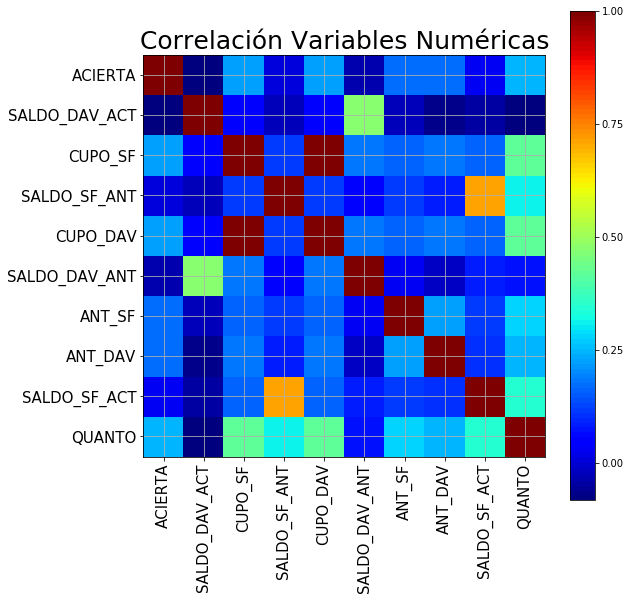

```python
#Se realiza y grafica la matriz de correlación de las variables continuas, para observar si hay información con alta probabilidad
#de estar duplicada, y poder elegir las mejores variables en el análisis.
def correlation_matrix(df):
    from matplotlib import pyplot as plt
    from matplotlib import cm as cm

    fig = plt.figure(figsize=(9, 9))
    ax1 = fig.add_subplot(111)
    cmap = cm.get_cmap('jet', 100)
    cax = ax1.imshow(df.corr(), interpolation="nearest", cmap=cmap)
    ax1.grid(True)
    plt.title('Correlación Variables Numéricas', fontsize=25)
    labels=list(df.columns.values)
    ax1.set_xticks(np.arange(10))
    ax1.set_xticklabels(labels,fontsize=15)
    ax1.set_yticks(np.arange(10))
    ax1.set_yticklabels(labels,fontsize=15)
    plt.xticks(rotation=90)
    # Add colorbar, make sure to specify tick locations to match desired ticklabels
    fig.colorbar(cax, ticks=[0,.25,.5,.75,1])
    plt.show()

correlation_matrix(datosfilt)
```

```python
#Se filtran las variables continúas que se consideran más relevantes en el problema
filtrar=['ACIERTA','QUANTO','ANT_DAV']
datosfilt=datos.loc[:,filtrar ]
```

```python
datosfilt
```

|  | ACIERTA | QUANTO | ANT_DAV |
| --- | --- | --- | --- |
| 0 | 894.0 | 14227.0 | 3.08 |
| 1 | 654.0 | 8322.0 | 14.08 |
| 2 | 806.0 | 1681.0 | 4.50 |
| 3 | 807.0 | 12661.0 | 1.50 |
| 4 | 823.0 | 1697.0 | 0.92 |
| 5 | 830.0 | 4248.0 | 2.00 |
| 6 | 873.0 | 16595.0 | 2.58 |
| 7 | 846.0 | 16462.0 | 5.58 |
| 8 | 741.0 | 3047.0 | 4.50 |
| 9 | 653.0 | 1093.0 | 0.33 |
| 10 | 790.0 | 3817.0 | 0.92 |
| 11 | 619.0 | 2674.0 | 2.50 |
| 12 | 851.0 | 3759.0 | 2.50 |
| 13 | 860.0 | 10856.0 | 4.42 |
| 14 | 763.0 | 1954.0 | 1.92 |
| 15 | 844.0 | 8744.0 | 13.25 |
| 16 | 795.0 | 6566.0 | 5.42 |
| 17 | 679.0 | 4662.0 | 1.08 |
| 18 | 739.0 | 4430.0 | 0.50 |
| 19 | 720.0 | 1474.0 | 9.00 |
| 20 | 873.0 | 9465.0 | 3.17 |
| 21 | 795.0 | 4181.0 | 2.50 |
| 22 | 845.0 | 5175.0 | 2.75 |
| 23 | 871.0 | 6666.0 | 2.50 |
| 24 | 760.0 | 1763.0 | 2.67 |
| 25 | 790.0 | 1970.0 | 2.00 |
| 26 | 801.0 | 4181.0 | 8.67 |
| 27 | 701.0 | 3362.0 | 0.25 |
| 28 | 729.0 | 5415.0 | 1.75 |
| 29 | 881.0 | 2525.0 | 1.67 |
| ... | ... | ... | ... |
| 10663 | 851.0 | 4181.0 | 13.25 |
| 10664 | 858.0 | 7138.0 | 1.75 |
| 10665 | 725.0 | 1904.0 | 0.42 |
| 10666 | 733.0 | 2873.0 | 2.08 |
| 10667 | 865.0 | 8521.0 | 1.67 |
| 10668 | 790.0 | 2368.0 | 10.50 |
| 10669 | 774.0 | 3999.0 | 4.67 |
| 10670 | 792.0 | 13895.0 | 2.50 |
| 10671 | 901.0 | 4181.0 | 2.50 |
| 10672 | 784.0 | 1962.0 | 0.58 |
| 10673 | 780.0 | 4869.0 | 4.75 |
| 10674 | 580.0 | 5142.0 | 11.17 |
| 10675 | 733.0 | 1532.0 | 1.25 |
| 10676 | 754.0 | 1035.0 | 0.33 |
| 10677 | 877.0 | 4181.0 | 2.50 |
| 10678 | 827.0 | 3585.0 | 1.75 |
| 10679 | 768.0 | 7825.0 | 5.75 |
| 10680 | 591.0 | 4786.0 | 0.83 |
| 10681 | 726.0 | 7891.0 | 3.00 |
| 10682 | 790.0 | 2343.0 | 0.33 |
| 10683 | 844.0 | 10517.0 | 1.25 |
| 10684 | 690.0 | 14367.0 | 17.17 |
| 10685 | 847.0 | 4910.0 | 0.67 |
| 10686 | 829.0 | 1979.0 | 0.33 |
| 10687 | 881.0 | 4181.0 | 15.42 |
| 10688 | 761.0 | 4140.0 | 1.50 |
| 10689 | 791.0 | 4181.0 | 2.50 |
| 10690 | 828.0 | 1134.0 | 1.00 |
| 10691 | 594.0 | 6384.0 | 3.58 |
| 10692 | 669.0 | 1631.0 | 1.17 |

10693 rows × 3 columns

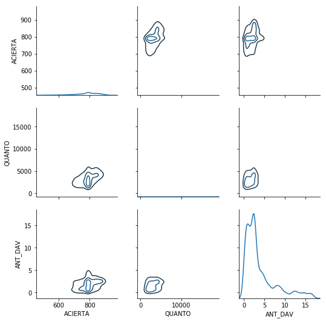

```python
#Se gráfica la distribución de probabilidad conjunta entre estas variables, para observar si existe una concentración
#particular de información dados unos parámetros definidos.
import seaborn as sns
g = sns.PairGrid(datosfilt)
g.map_diag(sns.kdeplot)
g.map_offdiag(sns.kdeplot, n_levels=3);
```

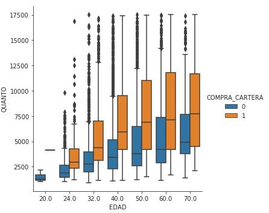

```python
#Se procede a explorar la variable Explicativa de COMPRA_CARTERA, POR INGRESOS y por EDAD, se puede observar que quienes compran cartera
#generalmente tienen más edad y mas ingresos.
with sns.axes_style(style='ticks'):
    g = sns.factorplot("EDAD", "QUANTO", "COMPRA_CARTERA", data=datos, kind="box")
    g.set_axis_labels("EDAD", "QUANTO");
```

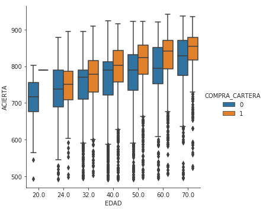

```python
#Se procede a explorar la variable Explicativa de COMPRA_CARTERA, POR SCORE y por EDAD, se puede observar que quienes compran cartera
#generalmente tienen más edad y mas score crediticio.
with sns.axes_style(style='ticks'):
    g = sns.factorplot("EDAD", "ACIERTA", "COMPRA_CARTERA", data=datos, kind="box")
    g.set_axis_labels("EDAD", "ACIERTA");
```

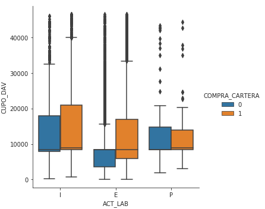

```python
#Se procede a explorar la variable Explicativa de COMPRA_CARTERA, POR cupo_dav y por act_lab, se puede observar que quienes compran cartera
#generalmente tienen más cupo y son empleados.
with sns.axes_style(style='ticks'):
    g = sns.factorplot("ACT_LAB", "CUPO_DAV", "COMPRA_CARTERA", data=datos, kind="box")
    g.set_axis_labels("ACT_LAB", "CUPO_DAV");
```

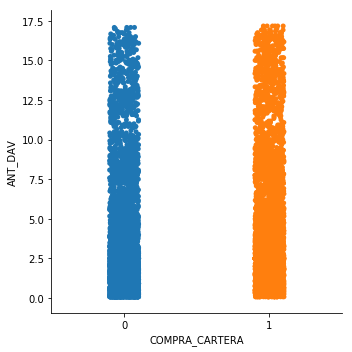

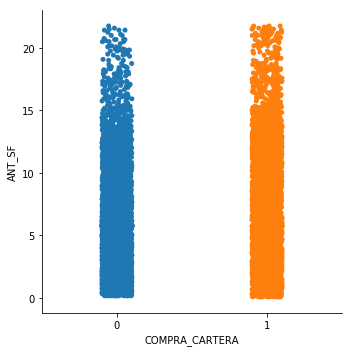

```python
#Se realiza un catplot para observar gráficamente si existe significancia en la variable COMPRA_CARTERA el comortamiento de antiguedad
#En Davivienda y en el sector financiero, se observa que parecen ser variables no significativa.
sns.catplot(x="COMPRA_CARTERA", y="ANT_DAV", order=[0, 1], data=datos);
sns.catplot(x="COMPRA_CARTERA_SF", y="ANT_SF", order=[0, 1], data=datos);
```

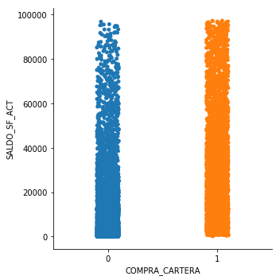

```python
#Se realiza un catplot para observar gráficamente si existe significancia en la variable COMPRA_CARTERA el comortamiento de saldo
#actual en el sector financiero, se observa que parece ser que entre mayor saldo mayor probabilidad de compra de cartera.
sns.catplot(x="COMPRA_CARTERA", y="SALDO_SF_ACT", order=[0, 1], data=datos);
```

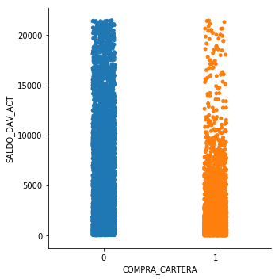

```python
#Se realiza un catplot para observar gráficamente si existe significancia en la variable COMPRA_CARTERA el comportamiento de saldo
#actual en Davivienda, se observa que parece ser que entre mayor saldo menor probabilidad de compra de cartera.
sns.catplot(x="COMPRA_CARTERA", y="SALDO_DAV_ACT", order=[0, 1], data=datos);
```

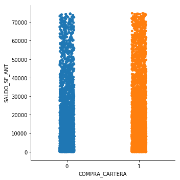

```python
#Se realiza un catplot para observar gráficamente si existe significancia en la variable COMPRA_CARTERA el comortamiento de saldo
#anterior en el sector financiero, se observa que parece ser que entre mayor saldo mayor probabilidad de compra de cartera.
sns.catplot(x="COMPRA_CARTERA", y="SALDO_SF_ANT", order=[0, 1], data=datos);
```

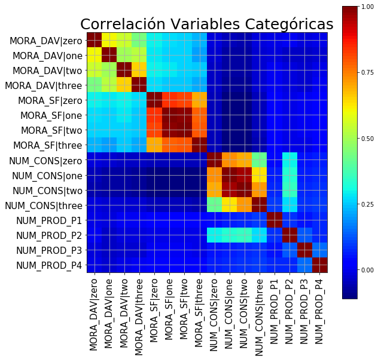

```python
#Se realiza y grafica la matriz de correlación de las variables dummies, para observar si hay información con alta probabilidad
#de estar duplicada, y poder elegir las mejores variables en el análisis.
datosfilt2=datos.loc[:,categoricas ]
datosfilt2=datosfilt2.loc[:,'MORA_DAV|zero':'NUM_PROD_P4' ]
def correlation_matrix2(df):
    from matplotlib import pyplot as plt
    from matplotlib import cm as cm

    fig = plt.figure(figsize=(9, 9))
    ax1 = fig.add_subplot(111)
    cmap = cm.get_cmap('jet', 100)
    cax = ax1.imshow(df.corr(), interpolation="nearest", cmap=cmap)
    ax1.grid(True)
    plt.title('Correlación Variables Categóricas', fontsize=25)
    labels=list(df.columns.values)
    ax1.set_xticks(np.arange(16))
    ax1.set_xticklabels(labels,fontsize=15)
    ax1.set_yticks(np.arange(16))
    ax1.set_yticklabels(labels,fontsize=15)
    plt.xticks(rotation=90)
    # Add colorbar, make sure to specify tick locations to match desired ticklabels
    fig.colorbar(cax, ticks=[0,.25,.5,.75,1])
    plt.show()

correlation_matrix2(datosfilt2)
```

```python
# Se observa que existen altas correlaciones entre todos los lags de la variable MORA_SF, entre todos los lags de MORA_DAV
#por lo que es convenientte seleccionar solo una combinación lineal de estas variables como parámetro.
```

```python
#Se visulaiza y explora el resultado de las variables anteriomente mencionadas
datosfilt2=datos.loc[:,categoricas ]
```

```python
datosfilt2.loc[:,'MORA_DAV|zero':'NUM_PROD_P4']
```

|  | MORA_DAV\|zero | MORA_DAV\|one | MORA_DAV\|two | MORA_DAV\|three | MORA_SF\|zero | MORA_SF\|one | MORA_SF\|two | MORA_SF\|three | NUM_CONS\|zero | NUM_CONS\|one | NUM_CONS\|two | NUM_CONS\|three | NUM_PROD_P1 | NUM_PROD_P2 | NUM_PROD_P3 | NUM_PROD_P4 |
| --- | --- | --- | --- | --- | --- | --- | --- | --- | --- | --- | --- | --- | --- | --- | --- | --- |
| 0 | 0.0 | 0.0 | 0.0 | 0.0 | 0.0 | 0.0 | 0.0 | 0.0 | 2.0 | 2.0 | 3.0 | 3.0 | 0.0 | 2.0 | 1.0 | 1.0 |
| 1 | 0.0 | 0.0 | 0.0 | 0.0 | 0.0 | 0.0 | 0.0 | 0.0 | 2.0 | 0.0 | 0.0 | 0.0 | 1.0 | 1.0 | 0.0 | 0.0 |
| 2 | 0.0 | 0.0 | 0.0 | 0.0 | 0.0 | 0.0 | 0.0 | 0.0 | 1.0 | 4.0 | 4.0 | 3.0 | 1.0 | 0.0 | 0.0 | 1.0 |
| 3 | 0.0 | 0.0 | 0.0 | 0.0 | 0.0 | 0.0 | 0.0 | 0.0 | 1.0 | 1.0 | 1.0 | 0.0 | 1.0 | 9.0 | 2.0 | 1.0 |
| 4 | 0.0 | 0.0 | 0.0 | 0.0 | 0.0 | 0.0 | 0.0 | 0.0 | 1.0 | 1.0 | 1.0 | 0.0 | 0.0 | 1.0 | 0.0 | 0.0 |
| 5 | 0.0 | 0.0 | 0.0 | 0.0 | 0.0 | 0.0 | 0.0 | 0.0 | 3.0 | 3.0 | 3.0 | 1.0 | 0.0 | 5.0 | 1.0 | 0.0 |
| 6 | 0.0 | 0.0 | 0.0 | 0.0 | 0.0 | 0.0 | 0.0 | 0.0 | 0.0 | 0.0 | 0.0 | 0.0 | 5.0 | 1.0 | 0.0 | 0.0 |
| 7 | 0.0 | 0.0 | 0.0 | 0.0 | 0.0 | 0.0 | 0.0 | 0.0 | 0.0 | 1.0 | 1.0 | 2.0 | 0.0 | 0.0 | 3.0 | 3.0 |
| 8 | 0.0 | 0.0 | 0.0 | 0.0 | 0.0 | 0.0 | 0.0 | 0.0 | 1.0 | 1.0 | 1.0 | 0.0 | 2.0 | 0.0 | 1.0 | 1.0 |
| 9 | 0.0 | 0.0 | 0.0 | 0.0 | 0.0 | 0.0 | 0.0 | 0.0 | 0.0 | 0.0 | 0.0 | 0.0 | 0.0 | 0.0 | 0.0 | 0.0 |
| 10 | 0.0 | 0.0 | 0.0 | 0.0 | 0.0 | 0.0 | 0.0 | 0.0 | 0.0 | 0.0 | 0.0 | 0.0 | 0.0 | 0.0 | 1.0 | 0.0 |
| 11 | 0.0 | 0.0 | 0.0 | 0.0 | 0.0 | 0.0 | 0.0 | 0.0 | 3.0 | 2.0 | 2.0 | 3.0 | 0.0 | 0.0 | 0.0 | 0.0 |
| 12 | 0.0 | 0.0 | 0.0 | 0.0 | 0.0 | 0.0 | 0.0 | 0.0 | 0.0 | 0.0 | 0.0 | 0.0 | 0.0 | 0.0 | 1.0 | 0.0 |
| 13 | 0.0 | 0.0 | 0.0 | 0.0 | 0.0 | 0.0 | 0.0 | 0.0 | 2.0 | 2.0 | 2.0 | 0.0 | 0.0 | 2.0 | 1.0 | 0.0 |
| 14 | 0.0 | 0.0 | 0.0 | 0.0 | 0.0 | 0.0 | 0.0 | 0.0 | 0.0 | 0.0 | 0.0 | 0.0 | 0.0 | 0.0 | 0.0 | 0.0 |
| 15 | 0.0 | 0.0 | 0.0 | 0.0 | 0.0 | 0.0 | 0.0 | 0.0 | 1.0 | 1.0 | 1.0 | 0.0 | 0.0 | 3.0 | 1.0 | 0.0 |
| 16 | 0.0 | 0.0 | 0.0 | 0.0 | 0.0 | 0.0 | 0.0 | 0.0 | 0.0 | 0.0 | 0.0 | 0.0 | 0.0 | 0.0 | 0.0 | 0.0 |
| 17 | 0.0 | 0.0 | 0.0 | 0.0 | 0.0 | 0.0 | 0.0 | 0.0 | 1.0 | 1.0 | 1.0 | 2.0 | 0.0 | 2.0 | 1.0 | 2.0 |
| 18 | 0.0 | 0.0 | 0.0 | 0.0 | 0.0 | 0.0 | 0.0 | 0.0 | 1.0 | 1.0 | 1.0 | 0.0 | 0.0 | 2.0 | 0.0 | 0.0 |
| 19 | 0.0 | 0.0 | 0.0 | 0.0 | 0.0 | 0.0 | 0.0 | 0.0 | 1.0 | 1.0 | 1.0 | 0.0 | 0.0 | 0.0 | 0.0 | 0.0 |
| 20 | 0.0 | 0.0 | 0.0 | 0.0 | 0.0 | 0.0 | 0.0 | 0.0 | 0.0 | 0.0 | 0.0 | 0.0 | 1.0 | 0.0 | 0.0 | 0.0 |
| 21 | 0.0 | 0.0 | 0.0 | 0.0 | 0.0 | 0.0 | 0.0 | 0.0 | 1.0 | 1.0 | 1.0 | 0.0 | 1.0 | 8.0 | 0.0 | 1.0 |
| 22 | 0.0 | 0.0 | 0.0 | 0.0 | 0.0 | 0.0 | 0.0 | 0.0 | 0.0 | 0.0 | 0.0 | 0.0 | 0.0 | 0.0 | 3.0 | 2.0 |
| 23 | 0.0 | 0.0 | 0.0 | 0.0 | 0.0 | 0.0 | 0.0 | 0.0 | 0.0 | 0.0 | 0.0 | 0.0 | 1.0 | 1.0 | 1.0 | 0.0 |
| 24 | 0.0 | 0.0 | 0.0 | 0.0 | 0.0 | 0.0 | 0.0 | 0.0 | 2.0 | 4.0 | 4.0 | 3.0 | 0.0 | 2.0 | 2.0 | 0.0 |
| 25 | 0.0 | 0.0 | 0.0 | 1.0 | 0.0 | 0.0 | 0.0 | 0.0 | 0.0 | 0.0 | 0.0 | 2.0 | 2.0 | 0.0 | 0.0 | 2.0 |
| 26 | 0.0 | 0.0 | 0.0 | 0.0 | 0.0 | 0.0 | 0.0 | 0.0 | 4.0 | 6.0 | 6.0 | 4.0 | 0.0 | 4.0 | 1.0 | 1.0 |
| 27 | 0.0 | 0.0 | 0.0 | 0.0 | 0.0 | 0.0 | 0.0 | 0.0 | 1.0 | 2.0 | 2.0 | 1.0 | 0.0 | 9.0 | 0.0 | 3.0 |
| 28 | 0.0 | 0.0 | 0.0 | 0.0 | 0.0 | 0.0 | 0.0 | 0.0 | 0.0 | 0.0 | 0.0 | 0.0 | 0.0 | 0.0 | 0.0 | 3.0 |
| 29 | 0.0 | 0.0 | 0.0 | 0.0 | 0.0 | 0.0 | 0.0 | 0.0 | 1.0 | 2.0 | 2.0 | 0.0 | 0.0 | 0.0 | 1.0 | 2.0 |
| ... | ... | ... | ... | ... | ... | ... | ... | ... | ... | ... | ... | ... | ... | ... | ... | ... |
| 10663 | 0.0 | 0.0 | 0.0 | 0.0 | 0.0 | 0.0 | 0.0 | 0.0 | 0.0 | 0.0 | 0.0 | 0.0 | 1.0 | 2.0 | 1.0 | 3.0 |
| 10664 | 0.0 | 0.0 | 0.0 | 0.0 | 0.0 | 0.0 | 0.0 | 0.0 | 1.0 | 2.0 | 2.0 | 0.0 | 0.0 | 2.0 | 0.0 | 0.0 |
| 10665 | 0.0 | 0.0 | 0.0 | 0.0 | 0.0 | 0.0 | 0.0 | 0.0 | 0.0 | 1.0 | 1.0 | 2.0 | 0.0 | 0.0 | 0.0 | 2.0 |
| 10666 | 0.0 | 0.0 | 0.0 | 0.0 | 0.0 | 0.0 | 0.0 | 0.0 | 4.0 | 3.0 | 3.0 | 0.0 | 0.0 | 0.0 | 2.0 | 0.0 |
| 10667 | 0.0 | 0.0 | 0.0 | 0.0 | 0.0 | 0.0 | 0.0 | 0.0 | 3.0 | 3.0 | 2.0 | 2.0 | 0.0 | 0.0 | 2.0 | 2.0 |
| 10668 | 1.0 | 1.0 | 1.0 | 1.0 | 0.0 | 0.0 | 0.0 | 0.0 | 0.0 | 0.0 | 0.0 | 0.0 | 0.0 | 0.0 | 1.0 | 0.0 |
| 10669 | 0.0 | 0.0 | 0.0 | 0.0 | 0.0 | 0.0 | 0.0 | 0.0 | 1.0 | 1.0 | 1.0 | 0.0 | 0.0 | 5.0 | 2.0 | 0.0 |
| 10670 | 0.0 | 0.0 | 0.0 | 0.0 | 0.0 | 0.0 | 0.0 | 0.0 | 1.0 | 1.0 | 1.0 | 0.0 | 2.0 | 1.0 | 2.0 | 1.0 |
| 10671 | 0.0 | 0.0 | 0.0 | 0.0 | 0.0 | 0.0 | 0.0 | 0.0 | 1.0 | 1.0 | 1.0 | 1.0 | 8.0 | 0.0 | 0.0 | 0.0 |
| 10672 | 0.0 | 0.0 | 0.0 | 0.0 | 0.0 | 0.0 | 0.0 | 0.0 | 1.0 | 1.0 | 1.0 | 0.0 | 0.0 | 1.0 | 0.0 | 0.0 |
| 10673 | 0.0 | 0.0 | 0.0 | 0.0 | 0.0 | 0.0 | 0.0 | 0.0 | 0.0 | 0.0 | 0.0 | 0.0 | 0.0 | 1.0 | 2.0 | 0.0 |
| 10674 | 0.0 | 0.0 | 0.0 | 0.0 | 0.0 | 0.0 | 0.0 | 0.0 | 1.0 | 1.0 | 1.0 | 0.0 | 0.0 | 0.0 | 1.0 | 0.0 |
| 10675 | 0.0 | 0.0 | 0.0 | 0.0 | 0.0 | 0.0 | 0.0 | 0.0 | 0.0 | 0.0 | 0.0 | 0.0 | 0.0 | 0.0 | 0.0 | 1.0 |
| 10676 | 0.0 | 0.0 | 0.0 | 0.0 | 0.0 | 0.0 | 0.0 | 0.0 | 0.0 | 0.0 | 0.0 | 0.0 | 0.0 | 0.0 | 1.0 | 1.0 |
| 10677 | 0.0 | 0.0 | 0.0 | 0.0 | 0.0 | 0.0 | 0.0 | 0.0 | 1.0 | 1.0 | 1.0 | 0.0 | 4.0 | 2.0 | 0.0 | 0.0 |
| 10678 | 0.0 | 0.0 | 0.0 | 0.0 | 0.0 | 0.0 | 0.0 | 0.0 | 1.0 | 1.0 | 1.0 | 0.0 | 0.0 | 1.0 | 1.0 | 0.0 |
| 10679 | 0.0 | 0.0 | 0.0 | 0.0 | 0.0 | 0.0 | 0.0 | 0.0 | 1.0 | 0.0 | 0.0 | 1.0 | 5.0 | 0.0 | 1.0 | 0.0 |
| 10680 | 0.0 | 0.0 | 0.0 | 0.0 | 0.0 | 0.0 | 0.0 | 0.0 | 1.0 | 2.0 | 2.0 | 0.0 | 1.0 | 2.0 | 0.0 | 5.0 |
| 10681 | 0.0 | 0.0 | 0.0 | 0.0 | 0.0 | 0.0 | 0.0 | 0.0 | 3.0 | 1.0 | 1.0 | 0.0 | 0.0 | 12.0 | 0.0 | 0.0 |
| 10682 | 0.0 | 1.0 | 0.0 | 0.0 | 1.0 | 1.0 | 1.0 | 0.0 | 0.0 | 0.0 | 0.0 | 0.0 | 0.0 | 1.0 | 0.0 | 0.0 |
| 10683 | 0.0 | 0.0 | 0.0 | 0.0 | 0.0 | 0.0 | 0.0 | 0.0 | 1.0 | 1.0 | 5.0 | 5.0 | 0.0 | 4.0 | 0.0 | 0.0 |
| 10684 | 0.0 | 0.0 | 0.0 | 0.0 | 0.0 | 0.0 | 0.0 | 0.0 | 2.0 | 2.0 | 2.0 | 1.0 | 0.0 | 2.0 | 0.0 | 0.0 |
| 10685 | 0.0 | 0.0 | 0.0 | 0.0 | 0.0 | 0.0 | 0.0 | 0.0 | 0.0 | 0.0 | 0.0 | 1.0 | 0.0 | 0.0 | 1.0 | 1.0 |
| 10686 | 0.0 | 0.0 | 0.0 | 0.0 | 0.0 | 0.0 | 0.0 | 0.0 | 1.0 | 1.0 | 1.0 | 0.0 | 0.0 | 0.0 | 0.0 | 0.0 |
| 10687 | 0.0 | 0.0 | 0.0 | 0.0 | 0.0 | 0.0 | 0.0 | 0.0 | 1.0 | 1.0 | 1.0 | 0.0 | 0.0 | 2.0 | 3.0 | 1.0 |
| 10688 | 0.0 | 0.0 | 0.0 | 0.0 | 0.0 | 0.0 | 0.0 | 0.0 | 1.0 | 1.0 | 1.0 | 0.0 | 0.0 | 1.0 | 2.0 | 0.0 |
| 10689 | 0.0 | 0.0 | 0.0 | 0.0 | 0.0 | 0.0 | 0.0 | 0.0 | 1.0 | 2.0 | 2.0 | 1.0 | 0.0 | 2.0 | 2.0 | 1.0 |
| 10690 | 0.0 | 0.0 | 0.0 | 0.0 | 0.0 | 0.0 | 0.0 | 0.0 | 0.0 | 1.0 | 1.0 | 1.0 | 0.0 | 0.0 | 0.0 | 0.0 |
| 10691 | 0.0 | 1.0 | 1.0 | 1.0 | 0.0 | 1.0 | 1.0 | 1.0 | 1.0 | 0.0 | 0.0 | 0.0 | 2.0 | 2.0 | 0.0 | 1.0 |
| 10692 | 0.0 | 0.0 | 0.0 | 0.0 | 0.0 | 0.0 | 0.0 | 0.0 | 1.0 | 2.0 | 2.0 | 2.0 | 0.0 | 1.0 | 0.0 | 1.0 |

10693 rows × 16 columns

```python
#Se importa el paquete de Machine Learning, llamdo sklearn
import sklearn
import numpy as np
```

```python
#Se crean las siguientes variables:
#en_Mora_Dav si existe alguna mora en los meses que se tiene información del cliente
#en_Mora_SF si existe alguna mora en los meses que se tiene información del cliente
#NUM_CONS que representa el número total de consultas en centrales de riesgo en los últimos 3 meses
datos['en_Mora_Dav']=datos.apply(lambda row: bool(row['MORA_DAV|zero']) | bool(row['MORA_DAV|one'])|bool(row['MORA_DAV|two'])|bool(row['MORA_DAV|three']), axis=1)
datos['en_Mora_SF']=datos.apply(lambda row: bool(row['MORA_SF|zero']) | bool(row['MORA_SF|one'])|bool(row['MORA_SF|two'])|bool(row['MORA_SF|three']), axis=1)
datos['NUM_CONS']=datos.apply(lambda row: row['NUM_CONS|zero']+ row['NUM_CONS|one']+row['NUM_CONS|two']+row['NUM_CONS|three'], axis=1)
```

```python
#Se realiza un backup de la información
datosrep=datos.copy()
```

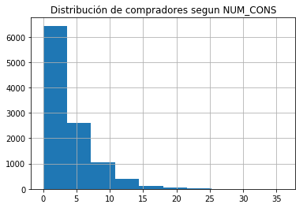

```python
#Se realiza el histograma de la nueva variable NUM_CONS para observar su consistencia.
datos['NUM_CONS'].hist().set_title('Distribución de compradores segun NUM_CONS')
plp.show()
```

```python
#Se crea una nueva variable CUPO_MAX/VALOR_INGRESOS, que indica el porcentaje de cupo sobre el total del ingreso, ya que se
#considera que esta relación de variables puede ser útil en si un cliente decide comprar cartera o no
datos['CUPO_MAX/VALOR_INGRESOS']=datos.apply(lambda row: row['CUPO_DAV']/row['QUANTO'] if row['QUANTO']!=0 else 0,axis=1)
```

```python
#Se crea una variable que indique el número total de productos en el SF, ya que si se tiene más productos es más probable que haya compra
#de cartera
datos['NPROD']=datos.apply(lambda row: row['NUM_PROD_P1']+row['NUM_PROD_P2']+row['NUM_PROD_P3']+row['NUM_PROD_P4'],axis=1)
```

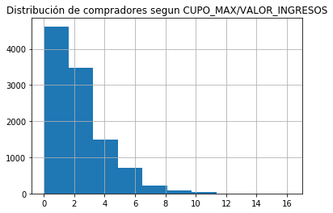

[figure not shown]

```python
#Se gráfica el histograma de las nuevas variables creadas, para observar su comportamiento y consistencia.
datos['CUPO_MAX/VALOR_INGRESOS'].hist().set_title('Distribución de compradores segun CUPO_MAX/VALOR_INGRESOS')
plp.show()
datos['NPROD'].hist().set_title('Distribución de compradores segun CUPO_MAX/VALOR_INGRESOS')
plp.show()
```

```python
#Se muestra el coeficiente de asimetría de cada variable ya que es conveniente que los datos enten centrados
#se observa fuertes asimetrías positivas, no obstante se procede a trabajar sin transformar las variables, dado a
#que se realizaron ambos casos y reultabn mejores resultados la variable sin transformar
datos.skew()
```

```
CONSECUTIVO                0.000000
COMPRA_CARTERA             0.252467
EDAD                       0.378960
ACIERTA                   -0.950878
QUANTO                     1.229519
ANT_DAV                    1.569365
SALDO_DAV_ANT              1.632846
SALDO_DAV_ACT              1.911312
CUPO_DAV                   1.702533
ANT_SF                     0.897903
SALDO_SF_ANT               1.912897
SALDO_SF_ACT               1.779947
CUPO_SF                    1.702533
NUM_PROD_P1                3.500598
NUM_PROD_P2                4.206536
NUM_PROD_P3                1.246058
NUM_PROD_P4                4.858025
MORA_DAV|zero              6.507209
MORA_DAV|one               4.756929
MORA_DAV|two               6.821899
MORA_DAV|three             5.453457
MORA_SF|zero               4.279363
MORA_SF|one                4.455448
MORA_SF|two                4.510749
MORA_SF|three              4.693775
NUM_CONS|zero              1.590032
NUM_CONS|one               1.559129
NUM_CONS|two               1.514326
NUM_CONS|three             2.178113
en_Mora_Dav                3.900905
en_Mora_SF                 3.757722
NUM_CONS                   1.524398
CUPO_MAX/VALOR_INGRESOS    1.567319
NPROD                      2.476550
dtype: float64
```

```python
#Se convierten en dummies todas las variables discretas, es decir se crean nuevs columnas con la variable y la categoría indicando
#1 si ocurre y 0 si no.
categoricasausar=['EDAD','ACT_LAB','en_Mora_Dav','en_Mora_SF']
dummiesausar=pd.get_dummies(datos,columns=categoricasausar)
```

Después de analizar cada una de las variables, las que se decidieron incluir fueron:

-ACIERTA -> El score del individuo parece estar relacionado directamente con la variable compra cartera, además tiene sentido que un mayor score el inversionista sea más informado y prefiera las menores tasas del mercado sin importar la fidelización. -SALDO_DAV_ACTUAL, SALDO_SF_ACT -> Se seleccionaron las deudas del individuo como un determinante en la compra de cartera, únicamente se dejaron las actuales ya que las anteriores se encontraron fuertemente correlacionadas con las actuales. -ANT_DAV -> Se selecciona la variable de antigüedad únicamente en Davivienda ya que intuitivamente se considera que entre más años en el banco mayor fidelización. -NUM_CONS, N_PROD -> El número de consultas total en los 3 meses de información se consideró ya que permite dar mayor información del interés y movimientos del cliente en el sistema financiero. El número de productos también se considero como total independientemente de la entidad, ya que no se existe razón para pensar que los números en cierta entidad tengan mayor influencia en la variable explicativa que los de otra entidad. -CUPO_MAX/VALOR_INGRESOS -> Se calculó la relación entre el cupo máximo y el valor de los ingresos, ya que se considera que entre menor sea el cupo en relación a sus ingresos, mayor probabilidad hay de compra de cartera.

Variables dummies para EDAD, Actividad Laboral, En Mora Davivienda, En mora Sector financiero -> Se transformaron las variables categóricas anteriores, a dummies en donde cada categoría es una dummie con 1 si se cumple y 0 si no. Se seleccionaron estas variables ya que se encontraron significativas intuitivamente y en el análisis de la información. Las variables En mora Davivienda y en mora Sector financiero, presentan un valor de 1 si hubo mora independientemente del mes, ya que todos los lags estaban correlacionados.

```python
#Se seleccionan las variables a usar
columnasFinales=['ACIERTA','SALDO_DAV_ACT','SALDO_SF_ACT','ANT_DAV','NUM_CONS',
                'NPROD','CUPO_MAX/VALOR_INGRESOS','EDAD_20.0','EDAD_24.0','EDAD_32.0','EDAD_40.0','EDAD_50.0','EDAD_60.0','EDAD_70.0',
                'ACT_LAB_E','ACT_LAB_I','ACT_LAB_P','en_Mora_Dav_True','en_Mora_SF_True']
datospreprocesados=dummiesausar.loc[:,columnasFinales]
```

```python
#Se selecciona la variable resultado COMPRA_CARTERA
datospreprocesados.head()
resultado=dummiesausar.loc[:,'COMPRA_CARTERA']
```

Se procede a dividir los datos obtenidos en entrenamiento y prueba, dado el volumen suficiente de la información y las recomendaciones de la literatura, se seleccionara 20% como datos de prueba y 80% como datos de entrenamiento.

Usando la funcion model_selection de sklearn se realiza la partición de los datos en X_train, X_test, y_train, y_test

```python
from sklearn.model_selection import train_test_split

X_train, X_test, y_train, y_test = train_test_split(datospreprocesados,resultado , test_size=0.2)
print (X_train.shape, y_train.shape)
print (X_test.shape, y_test.shape)
```

```
(8554, 19) (8554,)
(2139, 19) (2139,)
```

```python
#Se separan las variables entre continuas y discretas
trainnumericas=X_train.loc[:,'ACIERTA':'CUPO_MAX/VALOR_INGRESOS']
traincategoricas=X_train.loc[:,'EDAD_20.0':'en_Mora_SF_True']
testnumericas=X_test.loc[:,'ACIERTA':'CUPO_MAX/VALOR_INGRESOS']
testcategoricas=X_test.loc[:,'EDAD_20.0':'en_Mora_SF_True']
```

```python
#Se estandarizan las variables continuas, restandole la media y dividiendo sobre la desviación-
from sklearn import preprocessing
scaler = preprocessing.StandardScaler().fit(trainnumericas)
trainnumt=scaler.transform(trainnumericas)
testnumt=scaler.transform(testnumericas)
```

```python
#Se transforman los dataframes en arreglos
traincategoricasA=traincategoricas.as_matrix()
```

```python
#Se concatenan las variables continuas estandarizadas y las variables discretas de los datos de entrenamiento
traindata2=np.concatenate((trainnumt,traincategoricasA),axis=1)
```

```python
#Se concatenan las variables continuas estandarizadas y las variables discretas de los datos de prueba
testcategoricasA=testcategoricas.as_matrix()
testdata2=np.concatenate((testnumt,testcategoricasA),axis=1)
```

```python
#Se realiza reducción de las variables por medio de componentes principales, de manera que se logre explicar al menos el 90%
#de la variabilidad, se seleccionan 9 variables que explican el 92% de la varianza
from sklearn.decomposition import PCA

pca = PCA(n_components = 9)

X_train = pca.fit_transform(traindata2)
X_test = pca.transform(testdata2)

explained_variance = pca.explained_variance_ratio_
```

```python
sum(explained_variance)
```

```
0.9240513217904586
```

A continuación se realizarán diferentes algoritmos de Machine Learning que permitan determinar la probabilidad de que un cliente pueda comprar cartera con base en las variables seleccionadas. Para realizar este procedimiento se tomaron en cuenta 3 algoritmos: Support Vector Machines, Redes Neuronales con capas ocultas y Adaboost con árboles de decisión como clasificador debil.

El alcance del proyecto únicamente se limitó a estos 3 metodos, dada los buenos resultados que los mismos han obtenido en la literatura, y por falta de tiempo y recursos tecnológicos para realizar otros metodos, no obstante se tuvieron en consideracón: Random Forest, otros algorítmos de boosting como el de gradiente estocástico y modelos paramétricos como son el Logit y el Probit.

En todos los modelos mostrados en este trabajo se realizó validación cruzada de k iteraciones que consiste en dividir los datos de entrenamiento en k muestras, tomar k-1 para entrenar el modelo y 1 para validarlo, y rotar los sets de elementos usados en cada tarea. Dadas las disposiciones tecnológicas y el tiempo, únicamente se tuvieron en cuenta 5 divisiones para la validación cruzada k=5. Para la validación cruzada en todos los metodos se utilizó la función cross_val_score.

El primer modelo que se tomó como referencia fue Support Vector Machines, aunque inicialmente la idea era probar el algoritmo con diferentes tipos de kernel (lineal, polínomico, gaussiano),por falta de tiempo únicamente se utilizó el kernel "Radial Basis Function", el cual tiene un hiperparametro adicional gamma.

A continuación se presenta el modelo de entrenamiento de SVM, para calcular los hiperparametros C (el factor de regularización) y gamma, se realizo una pequeña Grid Search en una escala logaritmica para ambos parametros, para gamma se tomaron 6 valores entre 10e-2 y 10e3, y para C entre 10e-2 y 10e8. Se escogieron estos rangos dado a que se prefiere la simplicidad en los modelos y el algoritmo tarda bastante en su entrenamiento con la tecnología actual. Se limitó el número máximo de iteraciones a 1000 para poder realizar el entrenamiento y el grid search rápidamente.

Los resultados del nivel de clasificación por cada hiperparametro se guarda en la variabe lista

```python
#Se crean valores posibles de gamma y C
gamma_range = np.logspace(-2, 3, 6)
C_range = np.logspace(-2, 8, 6)
```

```python
#Se realiza SVM con validaci´pn cruzada variando los datos de gamma y C
from sklearn.model_selection import cross_val_score
from sklearn import svm
lista=[]
for c in C_range:
    for gamma in gamma_range:
        clf = svm.SVC(kernel='rbf', C=c, gamma=gamma, max_iter=1000).fit(X_train, y_train)
        scores = cross_val_score(clf, X_train, y_train, cv=5)
        lista.append((np.mean(scores),c,gamma))
```

[output not shown]

[output cut: 377 more lines]

[output not shown]

```python
lista
```

```
[(0.5238488486948913, 0.01, 0.01),
 (0.5941098704290436, 0.01, 0.1),
 (0.5238476182663947, 0.01, 1.0),
 (0.5707266022058849, 0.01, 10.0),
 (0.6129382290716076, 0.01, 100.0),
 (0.584169101889733, 0.01, 1000.0),
 (0.4978953520563536, 1.0, 0.01),
 (0.5831233060246565, 1.0, 0.1),
 (0.6953489119252446, 1.0, 1.0),
 (0.6100089206066013, 1.0, 10.0),
 (0.6264972093198123, 1.0, 100.0),
 (0.5845198423684381, 1.0, 1000.0),
 (0.4408421599488689, 100.0, 0.01),
 (0.5781018589723872, 100.0, 0.1),
 (0.6301170616000354, 100.0, 1.0),
 (0.5755167970579087, 100.0, 10.0),
 (0.4486788274016426, 100.0, 100.0),
 (0.562076279731083, 100.0, 1000.0),
 (0.49251749088286656, 10000.0, 0.01),
 (0.5659442000676735, 10000.0, 0.1),
 (0.6304667083645212, 10000.0, 1.0),
 (0.5755167970579087, 10000.0, 10.0),
 (0.4486788274016426, 10000.0, 100.0),
 (0.562076279731083, 10000.0, 1000.0),
 (0.49251749088286656, 1000000.0, 0.01),
 (0.5659442000676735, 1000000.0, 0.1),
 (0.6304667083645212, 1000000.0, 1.0),
 (0.5755167970579087, 1000000.0, 10.0),
 (0.4486788274016426, 1000000.0, 100.0),
 (0.562076279731083, 1000000.0, 1000.0),
 (0.49251749088286656, 100000000.0, 0.01),
 (0.5659442000676735, 100000000.0, 0.1),
 (0.6304667083645212, 100000000.0, 1.0),
 (0.5755167970579087, 100000000.0, 10.0),
 (0.4486788274016426, 100000000.0, 100.0),
 (0.562076279731083, 100000000.0, 1000.0)]
```

```python
#Se crea un grid search más pequeño para ajustar los resultados de SVM
gamma_range = np.linspace(0.5,1.5 , 5)
from sklearn.model_selection import cross_val_score
from sklearn import svm
lista=[]

for gamma in gamma_range:
        clf = svm.SVC(kernel='rbf', C=1, gamma=gamma, max_iter=1000).fit(X_train, y_train)
        scores = cross_val_score(clf, X_train, y_train, cv=5)
        lista.append((np.mean(scores),1,gamma))
```

[output not shown]

[output cut: 20 more lines]

```python
#Se muestran los porcentajes de acierto en los datos de validación y sus parametros
lista
```

```
[(0.7169724623266719, 1, 0.5),
 (0.7180274180483354, 1, 0.75),
 (0.6953489119252446, 1, 1.0),
 (0.7023622176422939, 1, 1.25),
 (0.6873995919078819, 1, 1.5)]
```

```python
#Se entrena el algorítmo con los mejores hiperparámetros encontrados
#se usa el modelo para predecir las etiquetas de los datos de prueba y se guarda en y_res
clf = svm.SVC(kernel='rbf', C=1, gamma=0.75, max_iter=8000).fit(X_train, y_train)
yres=clf.predict(X_test)
```

```python
#Se calcula el porcentaje de éxito del algoritmo en los datos de prueba con y_test y yres
from sklearn.metrics import accuracy_score
resultado=accuracy_score(y_test,yres)
resultado
```

```
0.7713884992987378
```

Se observa que el mejor resultado se obtiene cuando gamma es 0.75 y c tiene un valor de 1, con estos resultados podría realizarse nuevamente grid_search para ajustar de mejor manera el valor de los hiperparametros, pero dado al tiempo y teconología disponibles, esto se saldrá del alcance de este ejercicio. Cabe resaltar que estos resultados pueden estar equivocos dada la limitación del máximo número de iteraciones. El nexito en los datos de prueba fue 77.14%

El segundo modelo que se utilizó fue el modelo de redes neuronales con capas ocultas, para este caso únicamente se consideró hasta dos capas ocultas, ya que entre más complejo sea el modelo, más dificil la estimación y menos deseable para el análisis, además que se contaba con poco tiempo. El número de neuronas escogida como hiperparametro para cada una de las capas se encontró por medio de una pequeña grid search, en donde se tomaron valores entre 1 y 21 neuronas para la primera capa y entre 0 y 20 para la segunda, se limitó nuevamente el número máximo de iteraciones hasta 150. El numero de particiones para la validación cruzada continúa siendo 5.

```python
#Se corre el algoritmo de redes neuronales variando el numero de neuronas en la capa 1 y en la capa 2, y realizando validación cruzada
from sklearn.neural_network import MLPClassifier

capa1 = np.linspace(1, 21, 5)
capa2 = np.linspace(0, 20, 5)
listarn=[]
for c1 in capa1:
    for c2 in capa2:
        c1=int(c1)
        c2=int(c2)
        if c2==0:
            mlp = MLPClassifier(hidden_layer_sizes=(c1,), max_iter=150, alpha=1e-4,
                    solver='sgd', verbose=10, tol=1e-3, random_state=1,
                    learning_rate_init=.1)
        else:
            mlp = MLPClassifier(hidden_layer_sizes=(c1,c2), max_iter=150, alpha=1e-4,
                    solver='sgd', verbose=10, tol=1e-3, random_state=1,
                    learning_rate_init=.1)
        mlp.fit(X_train, y_train)
        scores = cross_val_score(mlp, X_train, y_train, cv=5)
        listarn.append((np.mean(scores),c1,c2))
```

[output not shown]

[output cut: 9770 more lines]

[output not shown]

```python
#Se visualizan los resultados con sus parámetros
listarn
```

```
[(0.7555532314128396, 1, 0),
 (0.7596446795930015, 1, 5),
 (0.7575405785064648, 1, 10),
 (0.7540335155051079, 1, 15),
 (0.7568393709776096, 1, 20),
 (0.7748421804560104, 6, 0),
 (0.7709851972616131, 6, 5),
 (0.7785837084431321, 6, 10),
 (0.784194052245361, 6, 15),
 (0.7788179683574805, 6, 20),
 (0.775777716256353, 11, 0),
 (0.77717978952837, 11, 5),
 (0.7867659895892078, 11, 10),
 (0.790506902362081, 11, 15),
 (0.7958851053212614, 11, 20),
 (0.7784661341645561, 16, 0),
 (0.7902735994476744, 16, 5),
 (0.789690171268811, 16, 10),
 (0.7837276514879641, 16, 15),
 (0.7846619568598098, 16, 20),
 (0.7774147330141056, 21, 0),
 (0.7845463649382565, 21, 5),
 (0.7827928676161473, 21, 10),
 (0.7838446105522915, 21, 15),
 (0.7859494635673541, 21, 20)]
```

```python
#Se selecciona el algorítmo con mayor éxito que corresponde a 11 neuronas en la primera capa y 20 de la segunda,
#se entrena el algoritmo con estos parámetros
mlp = MLPClassifier(hidden_layer_sizes=(11,20), max_iter=150, alpha=1e-4,
                    solver='sgd', verbose=10, tol=1e-3, random_state=1,
                    learning_rate_init=.1)
mlp.fit(X_train, y_train)
```

[output not shown]

[output cut: 58 more lines]

[output not shown]

```
MLPClassifier(activation='relu', alpha=0.0001, batch_size='auto', beta_1=0.9,
       beta_2=0.999, early_stopping=False, epsilon=1e-08,
       hidden_layer_sizes=(11, 20), learning_rate='constant',
       learning_rate_init=0.1, max_iter=150, momentum=0.9,
       n_iter_no_change=10, nesterovs_momentum=True, power_t=0.5,
       random_state=1, shuffle=True, solver='sgd', tol=0.001,
       validation_fraction=0.1, verbose=10, warm_start=False)
```

```python
#Se calcula el porcentaje de éxito de las redes neuronales con los datos de prueba
yres=mlp.predict(X_test)
resultado=accuracy_score(y_test,yres)
resultado
```

```
0.8111266947171576
```

Se observa que el valor que minimiza el error corresponde a una red neuronal con 11 neuronas en la primera capa y 20 en la segunda, con un nivel de éxito de 81.11%, en los datos de prueba.